# R Notebook

# Libraries

```r
library(tidyverse)
library(janitor)
```

# MVP

## Q1 - Load the data, clean_names() and explore it.

```r
mobile_reviews <- read_csv("20190928-items.csv") %>% clean_names()
```

```r
mobile_reviews %>% names()
```

```
[1] "asin"          "brand"         "title"         "url"           "image"         "rating"
[7] "review_url"    "total_reviews" "prices"
```

```r
mobile_reviews %>% skimr::skim()
```

```
-- Data Summary ------------------------
                           Values
Name                       Piped data
Number of rows             792
Number of columns          9
_______________________
Column type frequency:
  character                7
  numeric                  2
________________________
Group variables            None
```

|  | skim_variable | n_missing | complete_rate | min | max | empty | n_unique | whitespace |
| --- | --- | --- | --- | --- | --- | --- | --- | --- |
| 1 | asin | 0 | 1.0000000 | 10 | 10 | 0 | 792 | 0 |
| 2 | brand | 0 | 1.0000000 | 4 | 8 | 0 | 10 | 0 |
| 3 | title | 0 | 1.0000000 | 19 | 200 | 0 | 785 | 0 |
| 4 | url | 0 | 1.0000000 | 60 | 97 | 0 | 792 | 0 |
| 5 | image | 0 | 1.0000000 | 87 | 87 | 0 | 719 | 0 |
| 6 | review_url | 0 | 1.0000000 | 49 | 49 | 0 | 792 | 0 |
| 7 | prices | 215 | 0.7285354 | 6 | 19 | 0 | 447 | 0 |

|  | skim_variable | n_missing | complete_rate | mean | sd | p0 | p25 | p50 | p75 | p100 | hist |
| --- | --- | --- | --- | --- | --- | --- | --- | --- | --- | --- | --- |
| 1 | rating | 0 | 1 | 3.607576 | 0.6687295 | 1 | 3.2 | 3.7 | 4.00 | 5 |  |
| 2 | total_reviews | 0 | 1 | 104.231061 | 166.2425030 | 1 | 7.0 | 31.5 | 122.25 | 984 |  |

```r
mobile_reviews
```

| asin | brand | title | url | image | rating | review_url | total_reviews | prices |
| --- | --- | --- | --- | --- | --- | --- | --- | --- |
| B0000SX2UC | Nokia | Dual-Band / Tri-Mode Sprint PCS Phone w/ Voice Activated Dialing & Bright White Backlit Screen | https://www.amazon.com/Dual-Band-Tri-Mode-Activated-Dialing-Backlit/dp/B0000SX2UC | https://m.media-amazon.com/images/I/2143EBQ210L._AC_UY218_SEARCH213888_FMwebp_QL75_.jpg | 3.0 | https://www.amazon.com/product-reviews/B0000SX2UC | 14 | NA |
| B0009N5L7K | Motorola | Motorola I265 phone | https://www.amazon.com/Motorola-i265-I265-phone/dp/B0009N5L7K | https://m.media-amazon.com/images/I/419WBAVDARL._AC_UY218_SEARCH213888_FMwebp_QL75_.jpg | 2.9 | https://www.amazon.com/product-reviews/B0009N5L7K | 7 | $49.95 |
| B000SKTZ0S | Motorola | MOTOROLA C168i AT&T CINGULAR PREPAID GOPHONE CELL PHONE | https://www.amazon.com/MOTOROLA-C168i-CINGULAR-PREPAID-GOPHONE/dp/B000SKTZ0S | https://m.media-amazon.com/images/I/71b+q3ydkIS._AC_UY218_SEARCH213888_FMwebp_QL75_.jpg | 2.6 | https://www.amazon.com/product-reviews/B000SKTZ0S | 22 | NA |
| B00198M12M | Nokia | Nokia 6500 Slide Black/silver Unlocked Cell Phone | https://www.amazon.com/Nokia-6500-Slide-silver-Unlocked/dp/B00198M12M | https://m.media-amazon.com/images/I/41ss4HpLkLL._AC_UY218_SEARCH213888_FMwebp_QL75_.jpg | 2.4 | https://www.amazon.com/product-reviews/B00198M12M | 5 | NA |
| B001AO4OUC | Motorola | Motorola i335 Cell Phone Boost Mobile | https://www.amazon.com/Motorola-i335-Phone-Boost-Mobile/dp/B001AO4OUC | https://m.media-amazon.com/images/I/710UO8gdT+L._AC_UY218_SEARCH213888_FMwebp_QL75_.jpg | 3.3 | https://www.amazon.com/product-reviews/B001AO4OUC | 21 | NA |
| B001DCJAJG | Motorola | Motorola V365 no contract cellular phone AT&T | https://www.amazon.com/Motorola-V365-contract-cellular-phone/dp/B001DCJAJG | https://m.media-amazon.com/images/I/61LYNCVrrKL._AC_UY218_SEARCH213888_FMwebp_QL75_.jpg | 3.2 | https://www.amazon.com/product-reviews/B001DCJAJG | 12 | NA |
| B001DZY4KI | Sony | Sony Ericsson G700 Triband GSM Phone Bronze (Unlocked) | https://www.amazon.com/Sony-Ericsson-Triband-Bronze-Unlocked/dp/B001DZY4KI | https://m.media-amazon.com/images/I/51mL10InzcL._AC_UY218_SEARCH213888_FMwebp_QL75_.jpg | 2.0 | https://www.amazon.com/product-reviews/B001DZY4KI | 1 | $78.99 |
| B001GQ3DJM | Nokia | Nokia 1680 Black Phone (T-Mobile) | https://www.amazon.com/Nokia-1680-Black-Phone-T-Mobile/dp/B001GQ3DJM | https://m.media-amazon.com/images/I/41X4VeqkFOL._AC_UY218_SEARCH213888_FMwebp_QL75_.jpg | 2.7 | https://www.amazon.com/product-reviews/B001GQ3DJM | 3 | NA |
| B0027VKQPE | Nokia | Nokia New 1100 for Tracfone | https://www.amazon.com/New-Nokia-1100-for-Tracfone/dp/B0027VKQPE | https://m.media-amazon.com/images/I/91IUe3nDP7L._AC_UY218_SEARCH213888_FMwebp_QL75_.jpg | 3.2 | https://www.amazon.com/product-reviews/B0027VKQPE | 8 | $99.99 |
| B00280QJFU | Samsung | Samsung T301G Prepaid Phone (Tracfone) | https://www.amazon.com/Samsung-T301G-Prepaid-Phone-Tracfone/dp/B00280QJFU | https://m.media-amazon.com/images/I/71QX+Kiri4L._AC_UY218_SEARCH213888_FMwebp_QL75_.jpg | 3.5 | https://www.amazon.com/product-reviews/B00280QJFU | 133 | $59.89 |

[output cut: 782 more lines]

## Q2 - Find the brand with the highest numbers of phones in the dataset.

Samsung - 392 phones

```r
mobile_reviews %>%
  group_by(brand) %>%
  summarise(count = n_distinct(title))
```

| brand | count |
| --- | --- |
| Apple | 100 |
| ASUS | 13 |
| Google | 32 |
| HUAWEI | 36 |
| Motorola | 100 |
| Nokia | 49 |
| OnePlus | 7 |
| Samsung | 392 |
| Sony | 29 |
| Xiaomi | 27 |

## Q3 - For your top brand, plot the distribution of phone ratings as a probability density, overlaying a fitted normal distribution. Do you think the normal distribution provides a good model of these ratings?

No, it’s not a very good fit. The relatively high probability bars in the “1” and “5” ratings indicate that there is a fair portion of the data here, which seems to indicate that the data doesn’t fit a normal distribution. In a normal distribution, there would be a relatively low probability of very high or very low ratings. The SD calculations below show that 99.7% of the data should lie in the range of 1.60 and 5.6. This is clearly not the case since there is a relatively high probability of a “1” rating. We can also see below that the Shapiro-Wilk test is violated here since the p value is statistically significant.

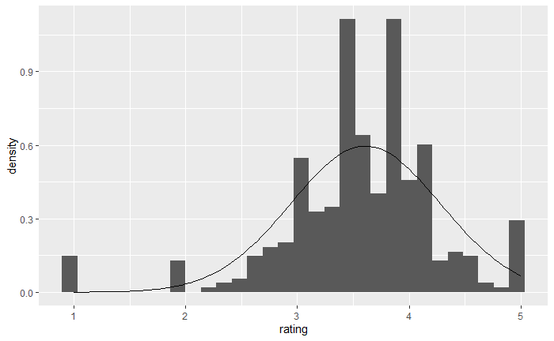

```r
mobile_reviews %>%
  filter(brand == "Samsung") %>%
  ggplot(aes(x = rating)) +
  geom_histogram(aes(y = ..density..)) +
  stat_function(
    fun = ~dnorm(.,mean = mean(mobile_reviews$rating),
                    sd = sd(mobile_reviews$rating))
  )
```

```r
#99.7% of the ratings should fall within 3 standard deviations of the mean.
sd(mobile_reviews$rating)*3 + mean(mobile_reviews$rating)
```

```
[1] 5.613764
```

```r
mean(mobile_reviews$rating) - sd(mobile_reviews$rating)*3
```

```
[1] 1.601387
```

```r
samsung_data <- mobile_reviews %>%
  filter(brand == "Samsung")

options(scipen = 99)
shapiro.test(samsung_data$rating)
```

```
    Shapiro-Wilk normality test

data:  samsung_data$rating
W = 0.92996, p-value = 0.000000000001088
```

## Q4 - We can be more quantitative in comparing the distribution of top brand ratings with a normal distribution. You calculated the mean() and sd() of your distribution in an earlier question. Use these values to calculate the proportions of ratings within one-, two- and three standard deviations of the mean. Compare these proportions with those you expect for a normal distribution.

Within one SD of mean: 2.939 - 4.276 Within two SD of mean: 2.270 - 4.945 Within three SD of mean: 1.601 - 5.614

Within One SD: 0.7657431  
Within Two SD: 0.9193955  
Within Three SD: 0.9798489  
With outliers: 1.0000000

Compared with the normal distribution: One SD - 68% - the samsung dataset has more Two SD - 95% - The samsung dataset has less within Two SDs Three SD - 99.7% - The samsung dataset has less within Two SDs.

Confirms that this data doesn’t fit a normal distribution.

```r
sd(mobile_reviews$rating)*1 + mean(mobile_reviews$rating)
```

```
[1] 4.276305
```

```r
mean(mobile_reviews$rating) - sd(mobile_reviews$rating)*1
```

```
[1] 2.938846
```

```r
sd(mobile_reviews$rating)*2 + mean(mobile_reviews$rating)
```

```
[1] 4.945035
```

```r
mean(mobile_reviews$rating) - sd(mobile_reviews$rating)*2
```

```
[1] 2.270117
```

```r
sd(mobile_reviews$rating)*3 + mean(mobile_reviews$rating)
```

```
[1] 5.613764
```

```r
mean(mobile_reviews$rating) - sd(mobile_reviews$rating)*3
```

```
[1] 1.601387
```

```r
samsung_data <- samsung_data %>%
  #add a column that shows whether a value lies within 1, 2 or 3 SDs of the mean
 mutate(num_sd =  case_when(
    between(rating, 2.939, 4.276) ~
            "One SD",
    between(rating,
            2.270, 4.945) ~
            "Two SD",
    between(rating,
            1.601, 5.614) ~
            "Three SD",
#keep any NAs because I can't remember if there were any
    is.na(rating) ~ NA_character_,
#assign all remaining values as outliers.
    TRUE ~ "Outlier"
  ), .after = rating)

samsung_data %>%
  #group by the number of SDs
  group_by(num_sd) %>%
  #summarise the number of ratings in each category
  summarise(count = n()) %>%
  #get the probability for each category of ratings
  mutate(prob = count / sum(count)) %>%
  #arrange in the correct order (to prep for cumsum)
  arrange(factor(num_sd, levels = c(
    "One SD",
    "Two SD",
    "Three SD",
    "Outlier"
  ))) %>%
  #get the cumulative sum of prob in a new column
  mutate(csum = cumsum(prob))
```

| num_sd | count | prob | csum |
| --- | --- | --- | --- |
| One SD | 304 | 0.76574307 | 0.7657431 |
| Two SD | 61 | 0.15365239 | 0.9193955 |
| Three SD | 24 | 0.06045340 | 0.9798489 |
| Outlier | 8 | 0.02015113 | 1.0000000 |

```r
NA
```